# Step 3: ROI-Wise catch22 Feature Analysis

## Cross-validated SVM classification

### 10-fold cross-validated linear SVM

I have chosen to use 10-fold cross validation via manual implementation, as the sample reweighting options in caret were limited and difficult to interpret.

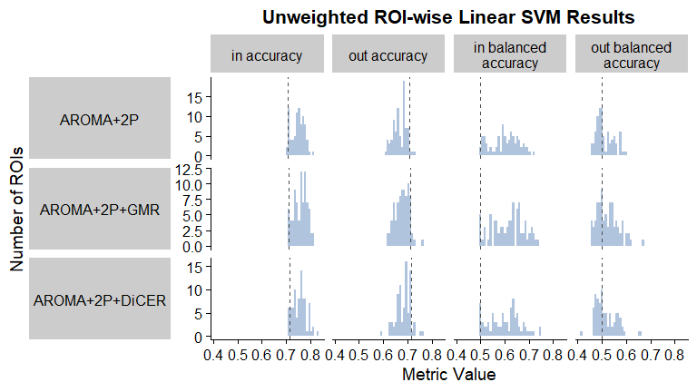

Interestingly, unlike the in-sample results, there is a fair spread of accuracy and balanced accuracy values outside of the proportions expected from classifying all subjects as controls.

However, there still is a balanced accuracy peak around 0.5, so we move forward with inverse probability reweighting.

### 10-fold cross-validated linear SVM with inverse probability weighting

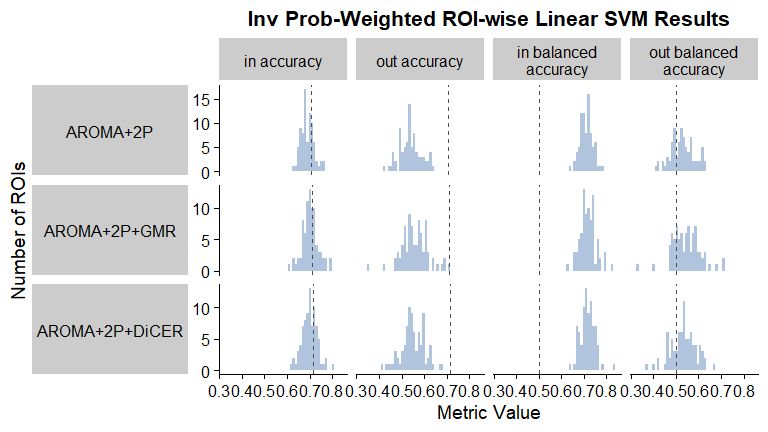

As with the in-sample results, the accuracy values are negatively shifted while the balanced accuracy values are positively shifted after applying inverse probability reweighting to the samples.

### 10-fold cross-validated linear SVM with SMOTE

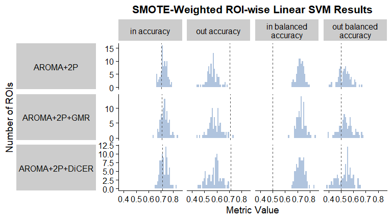

## Model-free shuffle null distribution

### Generating null distributions from model-free shuffles

This first model-free shuffles method is borrowed from Trent’s implementation in theft. With this method, the input class labels (Schz or Control) are randomly shuffled N times, and for each iteration, the classification accuracy and balanced accuracy are calculated. This yields a null distribution of accuracies and balanced accuracies, circumventing the need for running any classification algorithms across iterations.

Here, I’ve run 1,000,000 iterations of the model-free shuffle, generating 1,000,000 null values for Accuracy and Balanced Accuracy, respectively. Since this method is independent of brain region, the same null distribution can be used to compare with each brain region separately.

### CV linear SVM

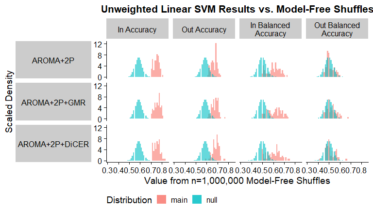

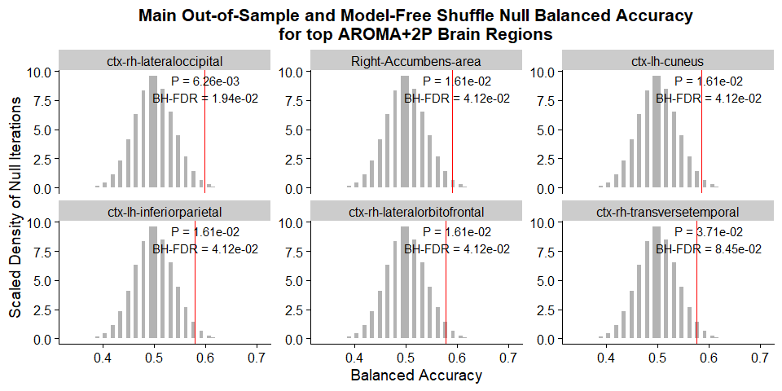

| Noise_Proc | Sample_Type | num_sig_acc | num_sig_acc_fdr | num_sig_bacc | num_sig_bacc_fdr |
| --- | --- | --- | --- | --- | --- |
| AROMA+2P | In-sample | 82 | 82 | 62 | 59 |
| AROMA+2P | Out-of-sample | 70 | 70 | 10 | 5 |
| AROMA+2P+GMR | In-sample | 82 | 82 | 63 | 57 |
| AROMA+2P+GMR | Out-of-sample | 76 | 76 | 17 | 11 |
| AROMA+2P+DiCER | In-sample | 82 | 82 | 58 | 52 |
| AROMA+2P+DiCER | Out-of-sample | 76 | 76 | 17 | 6 |

This table summarises the number of ROIs for which raw accuracy or balanced accuracy is significantly greater than the model-free shuffle null distribution, both before and after adjusting for multiple comparisons with BH-FDR.

### CV linear SVM – inv prob

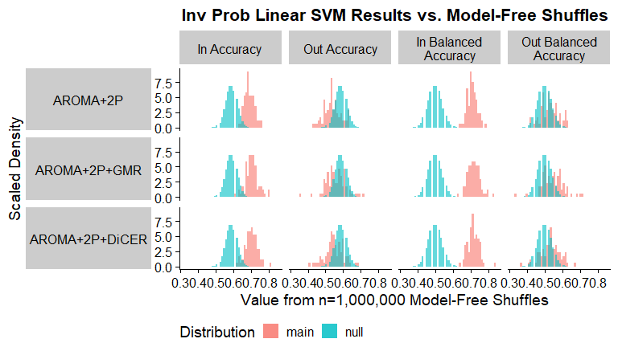

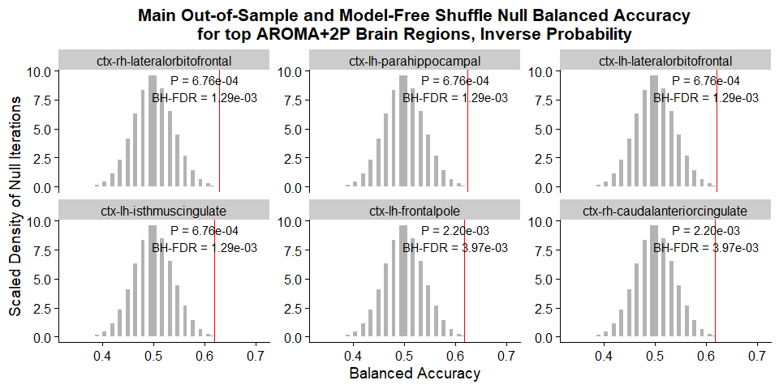

| Noise_Proc | Sample_Type | num_sig_acc | num_sig_acc_fdr | num_sig_bacc | num_sig_bacc_fdr |
| --- | --- | --- | --- | --- | --- |
| AROMA+2P | In-sample | 80 | 78 | 82 | 82 |
| AROMA+2P | Out-of-sample | 0 | 0 | 22 | 14 |
| AROMA+2P+GMR | In-sample | 79 | 77 | 82 | 82 |
| AROMA+2P+GMR | Out-of-sample | 7 | 5 | 30 | 25 |
| AROMA+2P+DiCER | In-sample | 78 | 75 | 82 | 82 |
| AROMA+2P+DiCER | Out-of-sample | 3 | 2 | 25 | 16 |

This table summarises the number of ROIs for which raw accuracy or balanced accuracy is significantly greater than the model-free shuffle null distribution, both before and after adjusting for multiple comparisons with BH-FDR.

### CV linear SVM – SMOTE

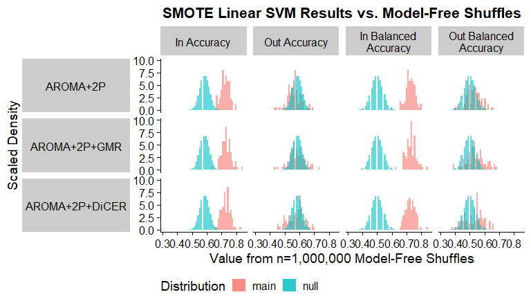

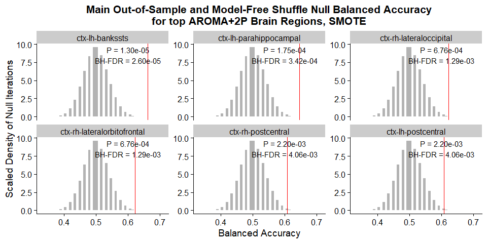

| Noise_Proc | Sample_Type | num_sig_acc | num_sig_acc_fdr | num_sig_bacc | num_sig_bacc_fdr |
| --- | --- | --- | --- | --- | --- |
| AROMA+2P | In-sample | 82 | 82 | 82 | 82 |
| AROMA+2P | Out-of-sample | 5 | 4 | 20 | 13 |
| AROMA+2P+GMR | In-sample | 81 | 81 | 82 | 82 |
| AROMA+2P+GMR | Out-of-sample | 10 | 9 | 29 | 21 |
| AROMA+2P+DiCER | In-sample | 82 | 82 | 82 | 82 |
| AROMA+2P+DiCER | Out-of-sample | 12 | 7 | 24 | 18 |

This table summarises the number of ROIs for which raw accuracy or balanced accuracy is significantly greater than the model-free shuffle null distribution, both before and after adjusting for multiple comparisons with BH-FDR.

## Empirical model-based pooled null distribution

### Unweighted

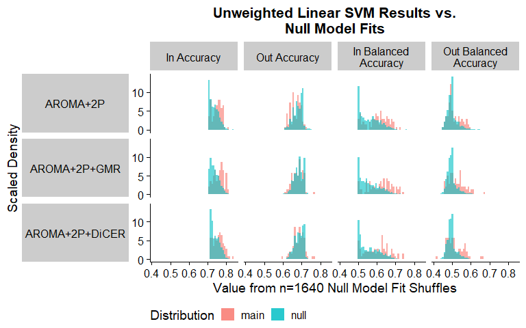

The fitted empirical null model distribution is fairly similar to the real accuracy and balanced accuracy values using in-sample linear SVM with no reweighting.

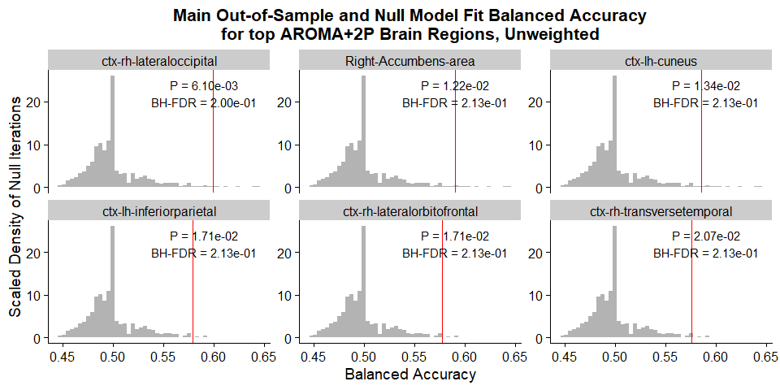

| Noise_Proc | Sample_Type | num_sig_acc | num_sig_acc_fdr | num_sig_bacc | num_sig_bacc_fdr |
| --- | --- | --- | --- | --- | --- |
| AROMA+2P | In-sample | 14 | 0 | 15 | 0 |
| AROMA+2P | Out-of-sample | 3 | 0 | 12 | 0 |
| AROMA+2P+GMR | In-sample | 18 | 0 | 18 | 1 |
| AROMA+2P+GMR | Out-of-sample | 6 | 1 | 17 | 1 |
| AROMA+2P+DiCER | In-sample | 12 | 3 | 13 | 3 |
| AROMA+2P+DiCER | Out-of-sample | 7 | 2 | 19 | 2 |

### Inverse probability weighted

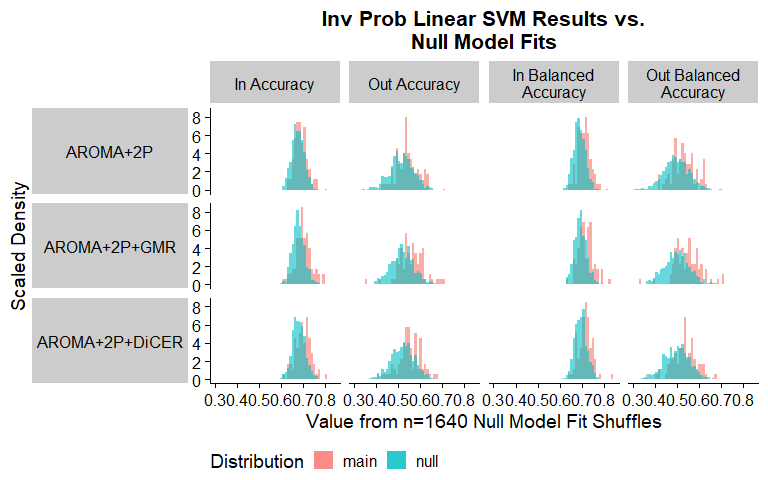

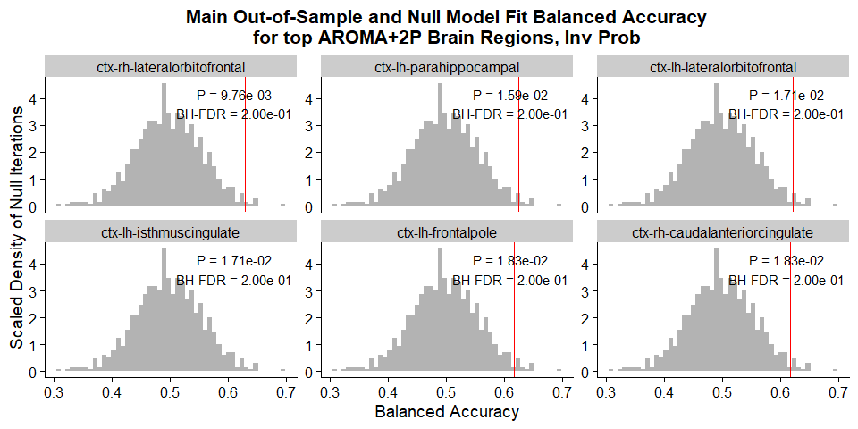

| Noise_Proc | Sample_Type | num_sig_acc | num_sig_acc_fdr | num_sig_bacc | num_sig_bacc_fdr |
| --- | --- | --- | --- | --- | --- |
| AROMA+2P | In-sample | 9 | 0 | 15 | 0 |
| AROMA+2P | Out-of-sample | 9 | 0 | 12 | 0 |
| AROMA+2P+GMR | In-sample | 16 | 4 | 13 | 3 |
| AROMA+2P+GMR | Out-of-sample | 15 | 4 | 14 | 3 |
| AROMA+2P+DiCER | In-sample | 14 | 3 | 13 | 2 |
| AROMA+2P+DiCER | Out-of-sample | 10 | 2 | 11 | 1 |

### SMOTE

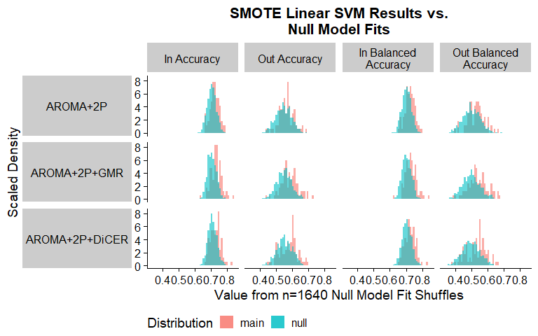

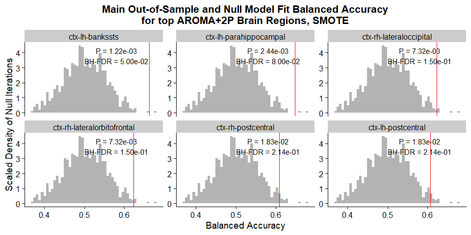

| Noise_Proc | Sample_Type | num_sig_acc | num_sig_acc_fdr | num_sig_bacc | num_sig_bacc_fdr |
| --- | --- | --- | --- | --- | --- |
| AROMA+2P | In-sample | 14 | 2 | 15 | 2 |
| AROMA+2P | Out-of-sample | 8 | 1 | 10 | 0 |
| AROMA+2P+GMR | In-sample | 20 | 5 | 24 | 4 |
| AROMA+2P+GMR | Out-of-sample | 14 | 5 | 14 | 1 |
| AROMA+2P+DiCER | In-sample | 16 | 2 | 16 | 2 |
| AROMA+2P+DiCER | Out-of-sample | 12 | 4 | 10 | 4 |

## Comparing model-free shuffle with pooled empirical null distributions

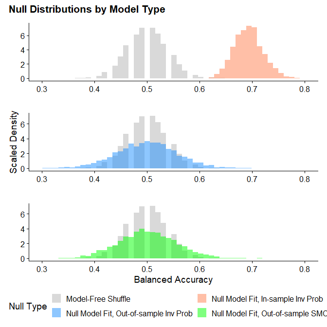